# Archivos Binarios Serializables

## Temas

- Superclase Object de Java
- Casting o conversion de tipos
- Repaso programa ejemplo con archivos texto con formato
  - Adición metodos guardarse/recuperarse en Estudiante
  - Adición de leer al inicio archivo y escribir al final
    - Chequear si existe el archivo con File.exists
- Archivos binarios (serializables)
- Se debe trabaja en netbeans (entorno de desarrollo más real)
  - Manejar el proyecto: editar, compilar, manejar errores
  - Completar código de forma automática:
    - Imports
    - Excepciones
    - Formatear el código
    - ....

## Superclase Object

- La superclase de donde se derivan todas las clases de java
- Ejemplo:
  - Object:

    ```
    - Animal
         - Mamiferos
           - Vaca
           - Perro
           - Gato
         - Omnivoros
           - Gallina
           - Aguila
    - Estudiante
    - ArrayList
    - ....
    ```

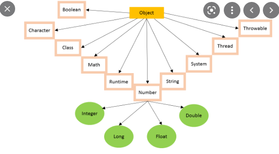

## Conversiones entre tipos de clases : Casting, Casteo

- Conversion entre diferentes tipos
- Para poder convertir entre tipos, estos deben "compatibles"

```java
// Casting de numeros
int a = 10;
long b = 20;  // Este tipo es como un entero más grande

a = b;
```

```
|   a = b;
incompatible types: possible lossy conversion from long to int
```

```java
// Conversion del long a entero : casting
a = (int)b;
System.out.println (a);
```

```
20
```

```java
// Conversion de decimal a entero
int x;+
double y = 10.56;

x = y;
```

```
|   double y = 10.56;
'.class' expected
```

```java
// Conversion de decimal a entero
int x;
double y = 10.56;

x = (int)y;
System.out.println (x);
```

```
10
```

```java
// Objeto "o" contiene una cadena pero no es de Clase cadena

Object o = new String ("Hola Mundo");

// Recupero esa cadena del objeto o
String s = (String) o;

// La uso como cadena
System.out.println (s);
s.contains("a")
```

```
Hola Mundo
```

```
true
```

## Clases para archivos texto con formato

- Lectura:
  - FileReader
  - BufferedReader
- Escritura
  - FileWriter
  - PrintWriter

## Clases para archivos binarios serializable

- Se escriben en y leen en formato binario objetos completos:
- Clases para la Lectura:
  - **FileInputStream** : Dispositivos de lectura desde archivos
  - **ObjectInputStream** : Flujo de datos binario para leer
- Clases para la Escritura:
  - **FileOutputStream** : Dispositivos de escritura en archivos
  - **ObjectOutputStream** : Flujo de datos binario para enviar
- Los clases de objetos que se van a escribir/leer deben ser serializable, es decir implementar la interface Serialiable

```java
// Ejemplo de clase que implementa la interface Serializable
class Estudiante implements Serializable {
//..
//..
}
```

## Ejemplos Archivos binarios serializable

```java
// Escritura
String nombre   = "Luis";
String correo   = "luis@gmail.com";
long    numero  = 11;

// Creación archivo para escribir flujo de datos binario
FileOutputStream fos = new FileOutputStream ("estudiantes-binario.dat");
ObjectOutputStream oos = new ObjectOutputStream (fos);

// Escritura con metodo writeObjetc
oos.writeObject (nombre);
oos.writeObject (correo);
oos.writeObject (numero);

// Cierro el flujo
oos.close ();
```

```java
// Lectura
String nombre;
String correo;
long    numero;

System.out.println ("Valores iniciales: ");
System.out.println (nombre + ", " + correo + "," + numero);

// Creación archivo para leer desde un flujo de datos binarios
FileInputStream fis = new FileInputStream ("estudiantes-binario.dat");
ObjectInputStream ois = new ObjectInputStream (fis);

// Lectura on metodo readObject
nombre = (String )ois.readObject();
correo = (String )ois.readObject();
numero = (long )ois.readObject();

System.out.println ("Valores recuperados: ");
System.out.println (nombre + ", " + correo + ", " + numero);
```

```
Valores iniciales:
null, null,0
Valores recuperados:
Luis, luis@gmail.com, 11
```

## Escritura/Lectura en binario de Objetos de Clase Estudiante

```java
public class Estudiante implements Serializable {
    // Atributos
    String nombres;
    String correoInstitucional;
    long numeroCelular;

    // Constructor
    public Estudiante () {
        this.nombres = "";
        this.correoInstitucional = "";
        this.numeroCelular = 0;
    }

    public Estudiante (String nombres, String correoInst, long nroCelular){
        this.nombres = nombres;
        this.correoInstitucional = correoInst;
        this.numeroCelular = nroCelular;
    }

    // Metodos
    public void presentarse () {
        System.out.println ("NOMBRES: " + nombres + " CORREO: " + correoInstitucional + " CELULAR" + numeroCelular);
    }
}
```

```java
// Escritura de Estudiante
Estudiante e1 = new Estudiante ("ana", "ana@gmail.com", 1234);

// Creación archivo para escribir flujo de datos binario
FileOutputStream fos = new FileOutputStream ("estudiante.dat");
ObjectOutputStream oos = new ObjectOutputStream (fos);

// Escritura con metodo writeObject
oos.writeObject(e1);

// Cierro el flujo
oos.close ();
```

```java
// Lectura de Estudiante
// Creación archivo para leer desde un flujo de datos binarios
FileInputStream fis = new FileInputStream ("estudiante.dat");
ObjectInputStream ois = new ObjectInputStream (fis);

// Lectura con metodo readObject y la conversion (casting)
Estudiante e = (Estudiante)ois.readObject ();
e.presentarse ();
```

```
NOMBRES: ana CORREO: ana@gmail.com CELULAR1234
```

## Implementación serializable en el ejemplo de estudiantes

- Solo se modifica el DAO
  - Se crea un metodo guardarse() que se ejecuta cada que se modifica la lista del DAO
    - El metodo guardarse() escribe siempre toda la lista desde el inicio al final, es decir, el archivo siempre está actualizado.
    - Se guarda primero el numero de elementos y después se recorre la lista guardando cada estudiante
  - Se crea un método recuperarse que se ejecuta cuando en el metodo crear del DAO, es decir, cuando el controlador crea el DAO para iniciar el programa.
    - El metodo recuperarse abre el archivo y recupera primero el numero de elementos y despues en un ciclo recupera estudiante por estudiante y lo agrega a la lista del DAO.